# Risk Factor Analysis

## Outcome Variable

**Outcome Variable:** ever_stunted

## Predictor Variables

**Intervention Variable:** nrooms

**Adjustment Set:**

unadjusted

## Stratifying Variables

The analysis was stratified on these variable(s):

- agecat
- studyid
- country

## Data Summary

| agecat | studyid | country | A | n | nA | nAY0 | nAY1 |
| --- | --- | --- | --- | --- | --- | --- | --- |
| 3 months | ki0047075b-MAL-ED | BANGLADESH | 1 | 242 | 152 | 107 | 45 |
| 3 months | ki0047075b-MAL-ED | BANGLADESH | 2 | 242 | 50 | 37 | 13 |
| 3 months | ki0047075b-MAL-ED | BANGLADESH | 3 | 242 | 28 | 22 | 6 |
| 3 months | ki0047075b-MAL-ED | BANGLADESH | 4+ | 242 | 12 | 11 | 1 |
| 3 months | ki0047075b-MAL-ED | BRAZIL | 1 | 210 | 4 | 4 | 0 |
| 3 months | ki0047075b-MAL-ED | BRAZIL | 2 | 210 | 20 | 16 | 4 |
| 3 months | ki0047075b-MAL-ED | BRAZIL | 3 | 210 | 59 | 49 | 10 |
| 3 months | ki0047075b-MAL-ED | BRAZIL | 4+ | 210 | 127 | 108 | 19 |
| 3 months | ki0047075b-MAL-ED | INDIA | 1 | 235 | 84 | 62 | 22 |
| 3 months | ki0047075b-MAL-ED | INDIA | 2 | 235 | 78 | 50 | 28 |
| 3 months | ki0047075b-MAL-ED | INDIA | 3 | 235 | 48 | 38 | 10 |
| 3 months | ki0047075b-MAL-ED | INDIA | 4+ | 235 | 25 | 22 | 3 |
| 3 months | ki0047075b-MAL-ED | NEPAL | 1 | 236 | 52 | 43 | 9 |
| 3 months | ki0047075b-MAL-ED | NEPAL | 2 | 236 | 31 | 28 | 3 |
| 3 months | ki0047075b-MAL-ED | NEPAL | 3 | 236 | 22 | 17 | 5 |
| 3 months | ki0047075b-MAL-ED | NEPAL | 4+ | 236 | 131 | 112 | 19 |
| 3 months | ki0047075b-MAL-ED | PERU | 1 | 272 | 19 | 9 | 10 |
| 3 months | ki0047075b-MAL-ED | PERU | 2 | 272 | 52 | 34 | 18 |
| 3 months | ki0047075b-MAL-ED | PERU | 3 | 272 | 62 | 41 | 21 |
| 3 months | ki0047075b-MAL-ED | PERU | 4+ | 272 | 139 | 94 | 45 |
| 3 months | ki0047075b-MAL-ED | SOUTH AFRICA | 1 | 257 | 14 | 12 | 2 |
| 3 months | ki0047075b-MAL-ED | SOUTH AFRICA | 2 | 257 | 22 | 16 | 6 |
| 3 months | ki0047075b-MAL-ED | SOUTH AFRICA | 3 | 257 | 25 | 18 | 7 |
| 3 months | ki0047075b-MAL-ED | SOUTH AFRICA | 4+ | 257 | 196 | 141 | 55 |
| 3 months | ki0047075b-MAL-ED | TANZANIA, UNITED REPUBLIC OF | 1 | 250 | 13 | 9 | 4 |
| 3 months | ki0047075b-MAL-ED | TANZANIA, UNITED REPUBLIC OF | 2 | 250 | 63 | 44 | 19 |
| 3 months | ki0047075b-MAL-ED | TANZANIA, UNITED REPUBLIC OF | 3 | 250 | 66 | 51 | 15 |
| 3 months | ki0047075b-MAL-ED | TANZANIA, UNITED REPUBLIC OF | 4+ | 250 | 108 | 70 | 38 |
| 3 months | ki1000108-CMC-V-BCS-2002 | INDIA | 1 | 362 | 196 | 128 | 68 |
| 3 months | ki1000108-CMC-V-BCS-2002 | INDIA | 2 | 362 | 101 | 63 | 38 |

[output cut: 238 more lines]

The following strata were considered:

- agecat: 12 months, studyid: ki0047075b-MAL-ED, country: BANGLADESH
- agecat: 12 months, studyid: ki0047075b-MAL-ED, country: BRAZIL
- agecat: 12 months, studyid: ki0047075b-MAL-ED, country: INDIA
- agecat: 12 months, studyid: ki0047075b-MAL-ED, country: NEPAL
- agecat: 12 months, studyid: ki0047075b-MAL-ED, country: PERU
- agecat: 12 months, studyid: ki0047075b-MAL-ED, country: SOUTH AFRICA
- agecat: 12 months, studyid: ki0047075b-MAL-ED, country: TANZANIA, UNITED REPUBLIC OF
- agecat: 12 months, studyid: ki1000108-CMC-V-BCS-2002, country: INDIA
- agecat: 12 months, studyid: ki1000108-IRC, country: INDIA
- agecat: 12 months, studyid: ki1017093b-PROVIDE, country: BANGLADESH
- agecat: 12 months, studyid: ki1017093c-NIH-Crypto, country: BANGLADESH
- agecat: 12 months, studyid: ki1113344-GMS-Nepal, country: NEPAL
- agecat: 12 months, studyid: ki1114097-CONTENT, country: PERU
- agecat: 12 months, studyid: ki1135781-COHORTS, country: INDIA
- agecat: 18 months, studyid: ki0047075b-MAL-ED, country: BANGLADESH
- agecat: 18 months, studyid: ki0047075b-MAL-ED, country: BRAZIL
- agecat: 18 months, studyid: ki0047075b-MAL-ED, country: INDIA
- agecat: 18 months, studyid: ki0047075b-MAL-ED, country: NEPAL
- agecat: 18 months, studyid: ki0047075b-MAL-ED, country: PERU
- agecat: 18 months, studyid: ki0047075b-MAL-ED, country: SOUTH AFRICA
- agecat: 18 months, studyid: ki0047075b-MAL-ED, country: TANZANIA, UNITED REPUBLIC OF
- agecat: 18 months, studyid: ki1000108-CMC-V-BCS-2002, country: INDIA
- agecat: 18 months, studyid: ki1000108-IRC, country: INDIA
- agecat: 18 months, studyid: ki1017093b-PROVIDE, country: BANGLADESH
- agecat: 18 months, studyid: ki1017093c-NIH-Crypto, country: BANGLADESH
- agecat: 18 months, studyid: ki1113344-GMS-Nepal, country: NEPAL
- agecat: 18 months, studyid: ki1114097-CONTENT, country: PERU
- agecat: 24 months, studyid: ki0047075b-MAL-ED, country: BANGLADESH
- agecat: 24 months, studyid: ki0047075b-MAL-ED, country: BRAZIL
- agecat: 24 months, studyid: ki0047075b-MAL-ED, country: INDIA
- agecat: 24 months, studyid: ki0047075b-MAL-ED, country: NEPAL
- agecat: 24 months, studyid: ki0047075b-MAL-ED, country: PERU
- agecat: 24 months, studyid: ki0047075b-MAL-ED, country: SOUTH AFRICA
- agecat: 24 months, studyid: ki0047075b-MAL-ED, country: TANZANIA, UNITED REPUBLIC OF
- agecat: 24 months, studyid: ki1000108-CMC-V-BCS-2002, country: INDIA
- agecat: 24 months, studyid: ki1000108-IRC, country: INDIA
- agecat: 24 months, studyid: ki1017093b-PROVIDE, country: BANGLADESH
- agecat: 24 months, studyid: ki1017093c-NIH-Crypto, country: BANGLADESH
- agecat: 24 months, studyid: ki1113344-GMS-Nepal, country: NEPAL
- agecat: 24 months, studyid: ki1114097-CONTENT, country: PERU
- agecat: 3 months, studyid: ki0047075b-MAL-ED, country: BANGLADESH
- agecat: 3 months, studyid: ki0047075b-MAL-ED, country: BRAZIL
- agecat: 3 months, studyid: ki0047075b-MAL-ED, country: INDIA
- agecat: 3 months, studyid: ki0047075b-MAL-ED, country: NEPAL
- agecat: 3 months, studyid: ki0047075b-MAL-ED, country: PERU
- agecat: 3 months, studyid: ki0047075b-MAL-ED, country: SOUTH AFRICA
- agecat: 3 months, studyid: ki0047075b-MAL-ED, country: TANZANIA, UNITED REPUBLIC OF
- agecat: 3 months, studyid: ki1000108-CMC-V-BCS-2002, country: INDIA
- agecat: 3 months, studyid: ki1000108-IRC, country: INDIA
- agecat: 3 months, studyid: ki1017093b-PROVIDE, country: BANGLADESH
- agecat: 3 months, studyid: ki1017093c-NIH-Crypto, country: BANGLADESH
- agecat: 3 months, studyid: ki1113344-GMS-Nepal, country: NEPAL
- agecat: 3 months, studyid: ki1114097-CONTENT, country: PERU
- agecat: 3 months, studyid: ki1135781-COHORTS, country: INDIA
- agecat: 6 months, studyid: ki0047075b-MAL-ED, country: BANGLADESH
- agecat: 6 months, studyid: ki0047075b-MAL-ED, country: BRAZIL
- agecat: 6 months, studyid: ki0047075b-MAL-ED, country: INDIA
- agecat: 6 months, studyid: ki0047075b-MAL-ED, country: NEPAL
- agecat: 6 months, studyid: ki0047075b-MAL-ED, country: PERU
- agecat: 6 months, studyid: ki0047075b-MAL-ED, country: SOUTH AFRICA
- agecat: 6 months, studyid: ki0047075b-MAL-ED, country: TANZANIA, UNITED REPUBLIC OF
- agecat: 6 months, studyid: ki1000108-CMC-V-BCS-2002, country: INDIA
- agecat: 6 months, studyid: ki1000108-IRC, country: INDIA
- agecat: 6 months, studyid: ki1017093b-PROVIDE, country: BANGLADESH
- agecat: 6 months, studyid: ki1017093c-NIH-Crypto, country: BANGLADESH
- agecat: 6 months, studyid: ki1113344-GMS-Nepal, country: NEPAL
- agecat: 6 months, studyid: ki1114097-CONTENT, country: PERU

### Dropped Strata

Some strata were dropped due to rare outcomes:

- agecat: 3 months, studyid: ki0047075b-MAL-ED, country: BANGLADESH
- agecat: 3 months, studyid: ki0047075b-MAL-ED, country: BRAZIL
- agecat: 3 months, studyid: ki0047075b-MAL-ED, country: INDIA
- agecat: 3 months, studyid: ki0047075b-MAL-ED, country: NEPAL
- agecat: 3 months, studyid: ki0047075b-MAL-ED, country: SOUTH AFRICA
- agecat: 3 months, studyid: ki0047075b-MAL-ED, country: TANZANIA, UNITED REPUBLIC OF
- agecat: 3 months, studyid: ki1000108-CMC-V-BCS-2002, country: INDIA
- agecat: 3 months, studyid: ki1017093b-PROVIDE, country: BANGLADESH
- agecat: 6 months, studyid: ki0047075b-MAL-ED, country: BANGLADESH
- agecat: 6 months, studyid: ki0047075b-MAL-ED, country: BRAZIL
- agecat: 6 months, studyid: ki0047075b-MAL-ED, country: NEPAL
- agecat: 6 months, studyid: ki1017093b-PROVIDE, country: BANGLADESH
- agecat: 12 months, studyid: ki0047075b-MAL-ED, country: BANGLADESH
- agecat: 12 months, studyid: ki0047075b-MAL-ED, country: BRAZIL
- agecat: 12 months, studyid: ki0047075b-MAL-ED, country: NEPAL
- agecat: 12 months, studyid: ki0047075b-MAL-ED, country: TANZANIA, UNITED REPUBLIC OF
- agecat: 12 months, studyid: ki1000108-CMC-V-BCS-2002, country: INDIA
- agecat: 18 months, studyid: ki0047075b-MAL-ED, country: BANGLADESH
- agecat: 18 months, studyid: ki0047075b-MAL-ED, country: BRAZIL
- agecat: 18 months, studyid: ki0047075b-MAL-ED, country: PERU
- agecat: 18 months, studyid: ki0047075b-MAL-ED, country: TANZANIA, UNITED REPUBLIC OF
- agecat: 18 months, studyid: ki1000108-CMC-V-BCS-2002, country: INDIA
- agecat: 24 months, studyid: ki0047075b-MAL-ED, country: BANGLADESH
- agecat: 24 months, studyid: ki0047075b-MAL-ED, country: BRAZIL
- agecat: 24 months, studyid: ki0047075b-MAL-ED, country: PERU
- agecat: 24 months, studyid: ki0047075b-MAL-ED, country: TANZANIA, UNITED REPUBLIC OF
- agecat: 24 months, studyid: ki1000108-CMC-V-BCS-2002, country: INDIA
- agecat: 24 months, studyid: ki1000108-IRC, country: INDIA

## Methods Detail

We’re interested in the causal parameters $E[Y_a]$ for all values of $a \in \mathcal{A}$. These parameters represent the mean outcome if, possibly contrary to fact, we intervened to set all units to have $A=a$. Under the randomization and positivity assumptions, these are identified by the statistical parameters $\psi_a=E_W[E_{Y|A,W}(Y|A=a,W)]$. In addition, we’re interested in the mean of $Y$, $E[Y]$ under no intervention (the observed mean). We will estimate these parameters by using SuperLearner to fit the relevant likelihood factors – $E_{Y|A,W}(Y|A=a,W)$ and $p(A=a|W)$, and then updating our likelihood fit using a joint TMLE.

For unadjusted analyses ($W=\{\}$), initial likelihoods were estimated using Lrnr_glm to estimate the simple $E(Y|A)$ and Lrnr_mean to estimate $p(A)$. For adjusted analyses, a small library containing Lrnr_glmnet, Lrnr_xgboost, and Lrnr_mean was used.

Having estimated these parameters, we will then use the delta method to estimate relative risks and attributable risks relative to a prespecified baseline level of $A$.

# Results Detail

## Results Plots

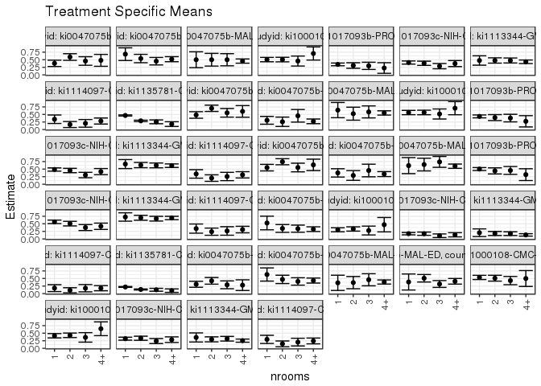

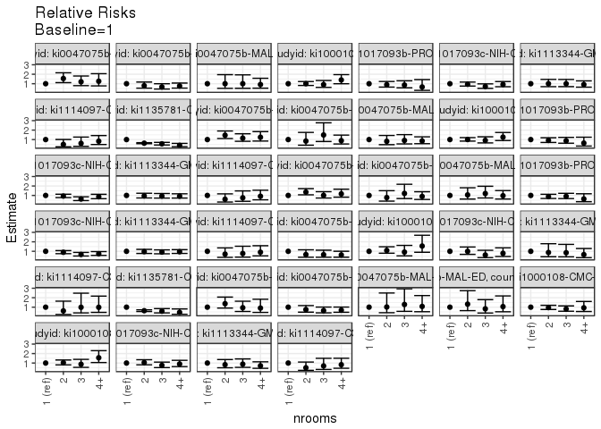

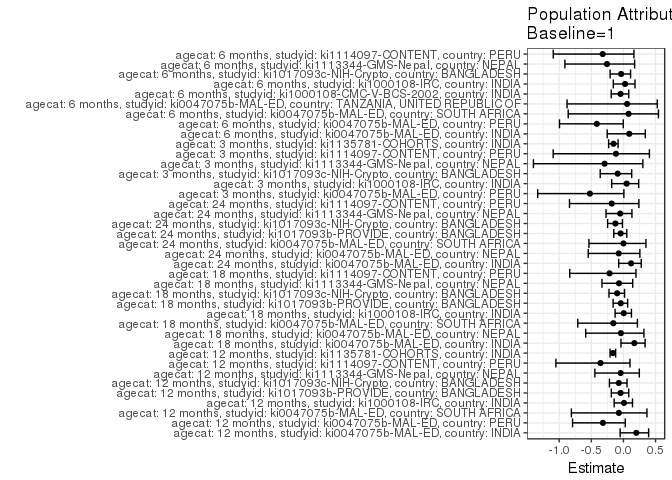

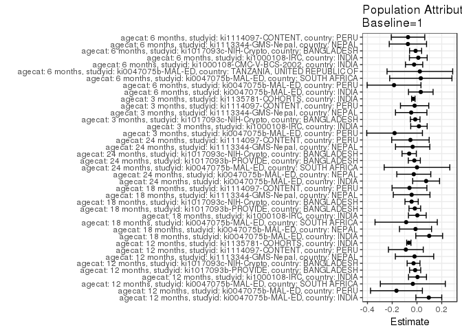

## Results Table

### Parameter: TSM

| agecat | studyid | country | intervention_level | baseline_level | estimate | ci_lower | ci_upper |
| --- | --- | --- | --- | --- | --- | --- | --- |
| 3 months | ki0047075b-MAL-ED | PERU | 1 | NA | 0.5263158 | 0.3013903 | 0.7512413 |
| 3 months | ki0047075b-MAL-ED | PERU | 2 | NA | 0.3461538 | 0.2166095 | 0.4756982 |
| 3 months | ki0047075b-MAL-ED | PERU | 3 | NA | 0.3387097 | 0.2206880 | 0.4567314 |
| 3 months | ki0047075b-MAL-ED | PERU | 4+ | NA | 0.3237410 | 0.2458126 | 0.4016694 |
| 3 months | ki1000108-IRC | INDIA | 1 | NA | 0.3027027 | 0.2364182 | 0.3689872 |
| 3 months | ki1000108-IRC | INDIA | 2 | NA | 0.3294118 | 0.2586736 | 0.4001500 |
| 3 months | ki1000108-IRC | INDIA | 3 | NA | 0.2777778 | 0.1312858 | 0.4242698 |
| 3 months | ki1000108-IRC | INDIA | 4+ | NA | 0.4705882 | 0.2330280 | 0.7081485 |
| 3 months | ki1017093c-NIH-Crypto | BANGLADESH | 1 | NA | 0.1739130 | 0.1351614 | 0.2126647 |
| 3 months | ki1017093c-NIH-Crypto | BANGLADESH | 2 | NA | 0.1727749 | 0.1191248 | 0.2264249 |
| 3 months | ki1017093c-NIH-Crypto | BANGLADESH | 3 | NA | 0.1057692 | 0.0466236 | 0.1649148 |
| 3 months | ki1017093c-NIH-Crypto | BANGLADESH | 4+ | NA | 0.1368421 | 0.0676864 | 0.2059978 |
| 3 months | ki1113344-GMS-Nepal | NEPAL | 1 | NA | 0.2051282 | 0.0782919 | 0.3319645 |
| 3 months | ki1113344-GMS-Nepal | NEPAL | 2 | NA | 0.1796875 | 0.1131206 | 0.2462544 |
| 3 months | ki1113344-GMS-Nepal | NEPAL | 3 | NA | 0.1744966 | 0.1135044 | 0.2354889 |
| 3 months | ki1113344-GMS-Nepal | NEPAL | 4+ | NA | 0.1335740 | 0.0934780 | 0.1736700 |
| 3 months | ki1114097-CONTENT | PERU | 1 | NA | 0.1818182 | 0.0675888 | 0.2960475 |
| 3 months | ki1114097-CONTENT | PERU | 2 | NA | 0.1111111 | 0.0270943 | 0.1951279 |
| 3 months | ki1114097-CONTENT | PERU | 3 | NA | 0.1794872 | 0.0587649 | 0.3002095 |
| 3 months | ki1114097-CONTENT | PERU | 4+ | NA | 0.1794872 | 0.0941236 | 0.2648507 |
| 3 months | ki1135781-COHORTS | INDIA | 1 | NA | 0.2200999 | 0.2061783 | 0.2340215 |
| 3 months | ki1135781-COHORTS | INDIA | 2 | NA | 0.1379081 | 0.1204631 | 0.1553531 |
| 3 months | ki1135781-COHORTS | INDIA | 3 | NA | 0.1276596 | 0.0799527 | 0.1753664 |
| 3 months | ki1135781-COHORTS | INDIA | 4+ | NA | 0.0990099 | 0.0407555 | 0.1572643 |
| 6 months | ki0047075b-MAL-ED | INDIA | 1 | NA | 0.3095238 | 0.2104507 | 0.4085969 |
| 6 months | ki0047075b-MAL-ED | INDIA | 2 | NA | 0.4230769 | 0.3132028 | 0.5329510 |
| 6 months | ki0047075b-MAL-ED | INDIA | 3 | NA | 0.2916667 | 0.1628074 | 0.4205260 |
| 6 months | ki0047075b-MAL-ED | INDIA | 4+ | NA | 0.2800000 | 0.1036200 | 0.4563800 |
| 6 months | ki0047075b-MAL-ED | PERU | 1 | NA | 0.6315789 | 0.4142788 | 0.8488791 |
| 6 months | ki0047075b-MAL-ED | PERU | 2 | NA | 0.4705882 | 0.3333475 | 0.6078290 |

[output cut: 126 more lines]

### Parameter: E(Y)

| agecat | studyid | country | intervention_level | baseline_level | estimate | ci_lower | ci_upper |
| --- | --- | --- | --- | --- | --- | --- | --- |
| 3 months | ki0047075b-MAL-ED | PERU | NA | NA | 0.3455882 | 0.3395922 | 0.3515843 |
| 3 months | ki1000108-IRC | INDIA | NA | NA | 0.3186275 | 0.3151614 | 0.3220935 |
| 3 months | ki1017093c-NIH-Crypto | BANGLADESH | NA | NA | 0.1596306 | 0.1578774 | 0.1613838 |
| 3 months | ki1113344-GMS-Nepal | NEPAL | NA | NA | 0.1585160 | 0.1565521 | 0.1604800 |
| 3 months | ki1114097-CONTENT | PERU | NA | NA | 0.1627907 | 0.1587789 | 0.1668025 |
| 3 months | ki1135781-COHORTS | INDIA | NA | NA | 0.1906412 | 0.1895266 | 0.1917559 |
| 6 months | ki0047075b-MAL-ED | INDIA | NA | NA | 0.3404255 | 0.3328641 | 0.3479869 |
| 6 months | ki0047075b-MAL-ED | PERU | NA | NA | 0.4464945 | 0.4399046 | 0.4530843 |
| 6 months | ki0047075b-MAL-ED | SOUTH AFRICA | NA | NA | 0.3882353 | 0.3852793 | 0.3911913 |
| 6 months | ki0047075b-MAL-ED | TANZANIA, UNITED REPUBLIC OF | NA | NA | 0.4080000 | 0.3995073 | 0.4164927 |
| 6 months | ki1000108-CMC-V-BCS-2002 | INDIA | NA | NA | 0.5122616 | 0.5087058 | 0.5158174 |
| 6 months | ki1000108-IRC | INDIA | NA | NA | 0.4261084 | 0.4212623 | 0.4309545 |
| 6 months | ki1017093c-NIH-Crypto | BANGLADESH | NA | NA | 0.3070652 | 0.3048713 | 0.3092591 |
| 6 months | ki1113344-GMS-Nepal | NEPAL | NA | NA | 0.2857143 | 0.2829560 | 0.2884725 |
| 6 months | ki1114097-CONTENT | PERU | NA | NA | 0.2232558 | 0.2163027 | 0.2302089 |
| 12 months | ki0047075b-MAL-ED | INDIA | NA | NA | 0.4765957 | 0.4654344 | 0.4877571 |
| 12 months | ki0047075b-MAL-ED | PERU | NA | NA | 0.5185185 | 0.5119238 | 0.5251133 |
| 12 months | ki0047075b-MAL-ED | SOUTH AFRICA | NA | NA | 0.4666667 | 0.4643928 | 0.4689406 |
| 12 months | ki1000108-IRC | INDIA | NA | NA | 0.5098522 | 0.5056474 | 0.5140570 |
| 12 months | ki1017093b-PROVIDE | BANGLADESH | NA | NA | 0.3316913 | 0.3295395 | 0.3338431 |
| 12 months | ki1017093c-NIH-Crypto | BANGLADESH | NA | NA | 0.3799726 | 0.3771016 | 0.3828436 |
| 12 months | ki1113344-GMS-Nepal | NEPAL | NA | NA | 0.4553265 | 0.4535872 | 0.4570657 |
| 12 months | ki1114097-CONTENT | PERU | NA | NA | 0.2511628 | 0.2425088 | 0.2598168 |
| 12 months | ki1135781-COHORTS | INDIA | NA | NA | 0.4000398 | 0.3975358 | 0.4025438 |
| 18 months | ki0047075b-MAL-ED | INDIA | NA | NA | 0.5807860 | 0.5687895 | 0.5927826 |
| 18 months | ki0047075b-MAL-ED | NEPAL | NA | NA | 0.2943723 | 0.2873573 | 0.3013873 |
| 18 months | ki0047075b-MAL-ED | SOUTH AFRICA | NA | NA | 0.5555556 | 0.5524961 | 0.5586150 |
| 18 months | ki1000108-IRC | INDIA | NA | NA | 0.5651106 | 0.5619528 | 0.5682683 |
| 18 months | ki1017093b-PROVIDE | BANGLADESH | NA | NA | 0.4172185 | 0.4144713 | 0.4199658 |
| 18 months | ki1017093c-NIH-Crypto | BANGLADESH | NA | NA | 0.4433566 | 0.4388523 | 0.4478610 |
| 18 months | ki1113344-GMS-Nepal | NEPAL | NA | NA | 0.6236934 | 0.6225644 | 0.6248224 |
| 18 months | ki1114097-CONTENT | PERU | NA | NA | 0.2803738 | 0.2734031 | 0.2873445 |
| 24 months | ki0047075b-MAL-ED | INDIA | NA | NA | 0.6228070 | 0.6113845 | 0.6342296 |
| 24 months | ki0047075b-MAL-ED | NEPAL | NA | NA | 0.3493450 | 0.3438790 | 0.3548109 |
| 24 months | ki0047075b-MAL-ED | SOUTH AFRICA | NA | NA | 0.6157025 | 0.6103156 | 0.6210893 |
| 24 months | ki1017093b-PROVIDE | BANGLADESH | NA | NA | 0.4810997 | 0.4778029 | 0.4843965 |
| 24 months | ki1017093c-NIH-Crypto | BANGLADESH | NA | NA | 0.5015773 | 0.4960526 | 0.5071020 |
| 24 months | ki1113344-GMS-Nepal | NEPAL | NA | NA | 0.6901408 | 0.6889390 | 0.6913426 |
| 24 months | ki1114097-CONTENT | PERU | NA | NA | 0.2893401 | 0.2840296 | 0.2946506 |

### Parameter: RR

| agecat | studyid | country | intervention_level | baseline_level | estimate | ci_lower | ci_upper |
| --- | --- | --- | --- | --- | --- | --- | --- |
| 3 months | ki0047075b-MAL-ED | PERU | 1 | 1 | 1.0000000 | 1.0000000 | 1.0000000 |
| 3 months | ki0047075b-MAL-ED | PERU | 2 | 1 | 0.6576923 | 0.3726646 | 1.1607198 |
| 3 months | ki0047075b-MAL-ED | PERU | 3 | 1 | 0.6435484 | 0.3707732 | 1.1170023 |
| 3 months | ki0047075b-MAL-ED | PERU | 4+ | 1 | 0.6151079 | 0.3766478 | 1.0045399 |
| 3 months | ki1000108-IRC | INDIA | 1 | 1 | 1.0000000 | 1.0000000 | 1.0000000 |
| 3 months | ki1000108-IRC | INDIA | 2 | 1 | 1.0882353 | 0.8008023 | 1.4788371 |
| 3 months | ki1000108-IRC | INDIA | 3 | 1 | 0.9176587 | 0.5184272 | 1.6243314 |
| 3 months | ki1000108-IRC | INDIA | 4+ | 1 | 1.5546218 | 0.8967031 | 2.6952612 |
| 3 months | ki1017093c-NIH-Crypto | BANGLADESH | 1 | 1 | 1.0000000 | 1.0000000 | 1.0000000 |
| 3 months | ki1017093c-NIH-Crypto | BANGLADESH | 2 | 1 | 0.9934555 | 0.6778969 | 1.4559054 |
| 3 months | ki1017093c-NIH-Crypto | BANGLADESH | 3 | 1 | 0.6081731 | 0.3331209 | 1.1103310 |
| 3 months | ki1017093c-NIH-Crypto | BANGLADESH | 4+ | 1 | 0.7868421 | 0.4529207 | 1.3669512 |
| 3 months | ki1113344-GMS-Nepal | NEPAL | 1 | 1 | 1.0000000 | 1.0000000 | 1.0000000 |
| 3 months | ki1113344-GMS-Nepal | NEPAL | 2 | 1 | 0.8759766 | 0.4260380 | 1.8010950 |
| 3 months | ki1113344-GMS-Nepal | NEPAL | 3 | 1 | 0.8506711 | 0.4181095 | 1.7307462 |
| 3 months | ki1113344-GMS-Nepal | NEPAL | 4+ | 1 | 0.6511733 | 0.3274831 | 1.2948045 |
| 3 months | ki1114097-CONTENT | PERU | 1 | 1 | 1.0000000 | 1.0000000 | 1.0000000 |
| 3 months | ki1114097-CONTENT | PERU | 2 | 1 | 0.6111111 | 0.2286479 | 1.6333269 |
| 3 months | ki1114097-CONTENT | PERU | 3 | 1 | 0.9871795 | 0.3932608 | 2.4780588 |
| 3 months | ki1114097-CONTENT | PERU | 4+ | 1 | 0.9871795 | 0.4489344 | 2.1707479 |
| 3 months | ki1135781-COHORTS | INDIA | 1 | 1 | 1.0000000 | 1.0000000 | 1.0000000 |
| 3 months | ki1135781-COHORTS | INDIA | 2 | 1 | 0.6265703 | 0.5439359 | 0.7217584 |
| 3 months | ki1135781-COHORTS | INDIA | 3 | 1 | 0.5800074 | 0.3970341 | 0.8473039 |
| 3 months | ki1135781-COHORTS | INDIA | 4+ | 1 | 0.4498407 | 0.2489207 | 0.8129363 |
| 6 months | ki0047075b-MAL-ED | INDIA | 1 | 1 | 1.0000000 | 1.0000000 | 1.0000000 |
| 6 months | ki0047075b-MAL-ED | INDIA | 2 | 1 | 1.3668639 | 0.9051379 | 2.0641241 |
| 6 months | ki0047075b-MAL-ED | INDIA | 3 | 1 | 0.9423077 | 0.5460799 | 1.6260327 |
| 6 months | ki0047075b-MAL-ED | INDIA | 4+ | 1 | 0.9046154 | 0.4462702 | 1.8337075 |
| 6 months | ki0047075b-MAL-ED | PERU | 1 | 1 | 1.0000000 | 1.0000000 | 1.0000000 |
| 6 months | ki0047075b-MAL-ED | PERU | 2 | 1 | 0.7450980 | 0.4746063 | 1.1697508 |

[output cut: 126 more lines]

### Parameter: PAR

| agecat | studyid | country | intervention_level | baseline_level | estimate | ci_lower | ci_upper |
| --- | --- | --- | --- | --- | --- | --- | --- |
| 3 months | ki0047075b-MAL-ED | PERU | 1 | NA | -0.1807276 | -0.4057330 | 0.0442779 |
| 3 months | ki1000108-IRC | INDIA | 1 | NA | 0.0159247 | -0.0504504 | 0.0822998 |
| 3 months | ki1017093c-NIH-Crypto | BANGLADESH | 1 | NA | -0.0142824 | -0.0530737 | 0.0245088 |
| 3 months | ki1113344-GMS-Nepal | NEPAL | 1 | NA | -0.0466122 | -0.1734637 | 0.0802393 |
| 3 months | ki1114097-CONTENT | PERU | 1 | NA | -0.0190275 | -0.1333272 | 0.0952723 |
| 3 months | ki1135781-COHORTS | INDIA | 1 | NA | -0.0294587 | -0.0434248 | -0.0154925 |
| 6 months | ki0047075b-MAL-ED | INDIA | 1 | NA | 0.0309017 | -0.0684595 | 0.1302630 |
| 6 months | ki0047075b-MAL-ED | PERU | 1 | NA | -0.1850845 | -0.4024846 | 0.0323156 |
| 6 months | ki0047075b-MAL-ED | SOUTH AFRICA | 1 | NA | 0.0310924 | -0.2204119 | 0.2825968 |
| 6 months | ki0047075b-MAL-ED | TANZANIA, UNITED REPUBLIC OF | 1 | NA | 0.0233846 | -0.2417438 | 0.2885131 |
| 6 months | ki1000108-CMC-V-BCS-2002 | INDIA | 1 | NA | -0.0230920 | -0.0927476 | 0.0465637 |
| 6 months | ki1000108-IRC | INDIA | 1 | NA | 0.0108078 | -0.0608397 | 0.0824554 |
| 6 months | ki1017093c-NIH-Crypto | BANGLADESH | 1 | NA | -0.0111166 | -0.0598565 | 0.0376233 |
| 6 months | ki1113344-GMS-Nepal | NEPAL | 1 | NA | -0.0732601 | -0.2239698 | 0.0774496 |
| 6 months | ki1114097-CONTENT | PERU | 1 | NA | -0.0721987 | -0.2075020 | 0.0631045 |
| 12 months | ki0047075b-MAL-ED | INDIA | 1 | NA | 0.0956434 | -0.0090249 | 0.2003117 |
| 12 months | ki0047075b-MAL-ED | PERU | 1 | NA | -0.1656920 | -0.3751930 | 0.0438089 |
| 12 months | ki0047075b-MAL-ED | SOUTH AFRICA | 1 | NA | -0.0333333 | -0.2957695 | 0.2291028 |
| 12 months | ki1000108-IRC | INDIA | 1 | NA | 0.0044174 | -0.0680348 | 0.0768696 |
| 12 months | ki1017093b-PROVIDE | BANGLADESH | 1 | NA | -0.0147290 | -0.0596357 | 0.0301777 |
| 12 months | ki1017093c-NIH-Crypto | BANGLADESH | 1 | NA | -0.0275419 | -0.0794320 | 0.0243482 |
| 12 months | ki1113344-GMS-Nepal | NEPAL | 1 | NA | -0.0196735 | -0.1745714 | 0.1352243 |
| 12 months | ki1114097-CONTENT | PERU | 1 | NA | -0.0897463 | -0.2303995 | 0.0509069 |
| 12 months | ki1135781-COHORTS | INDIA | 1 | NA | -0.0657262 | -0.0830412 | -0.0484113 |
| 18 months | ki0047075b-MAL-ED | INDIA | 1 | NA | 0.0988583 | -0.0095398 | 0.2072564 |
| 18 months | ki0047075b-MAL-ED | NEPAL | 1 | NA | -0.0117502 | -0.1412649 | 0.1177646 |
| 18 months | ki0047075b-MAL-ED | SOUTH AFRICA | 1 | NA | -0.0873016 | -0.3388131 | 0.1642099 |
| 18 months | ki1000108-IRC | INDIA | 1 | NA | 0.0029484 | -0.0686999 | 0.0745967 |
| 18 months | ki1017093b-PROVIDE | BANGLADESH | 1 | NA | -0.0173609 | -0.0644420 | 0.0297202 |
| 18 months | ki1017093c-NIH-Crypto | BANGLADESH | 1 | NA | -0.0432902 | -0.0968812 | 0.0103007 |
| 18 months | ki1113344-GMS-Nepal | NEPAL | 1 | NA | -0.0429733 | -0.1910548 | 0.1051082 |
| 18 months | ki1114097-CONTENT | PERU | 1 | NA | -0.0605353 | -0.2010965 | 0.0800260 |
| 24 months | ki0047075b-MAL-ED | INDIA | 1 | NA | 0.0740265 | -0.0345178 | 0.1825708 |
| 24 months | ki0047075b-MAL-ED | NEPAL | 1 | NA | -0.0256550 | -0.1630205 | 0.1117104 |
| 24 months | ki0047075b-MAL-ED | SOUTH AFRICA | 1 | NA | 0.0003179 | -0.2647469 | 0.2653826 |
| 24 months | ki1017093b-PROVIDE | BANGLADESH | 1 | NA | -0.0213394 | -0.0698903 | 0.0272116 |
| 24 months | ki1017093c-NIH-Crypto | BANGLADESH | 1 | NA | -0.0628826 | -0.1205569 | -0.0052084 |
| 24 months | ki1113344-GMS-Nepal | NEPAL | 1 | NA | -0.0348592 | -0.1733600 | 0.1036417 |
| 24 months | ki1114097-CONTENT | PERU | 1 | NA | -0.0527652 | -0.2040819 | 0.0985516 |

### Parameter: PAF

| agecat | studyid | country | intervention_level | baseline_level | estimate | ci_lower | ci_upper |
| --- | --- | --- | --- | --- | --- | --- | --- |
| 3 months | ki0047075b-MAL-ED | PERU | 1 | NA | -0.5229563 | -1.3358222 | 0.0070323 |
| 3 months | ki1000108-IRC | INDIA | 1 | NA | 0.0499792 | -0.1829063 | 0.2370152 |
| 3 months | ki1017093c-NIH-Crypto | BANGLADESH | 1 | NA | -0.0894718 | -0.3617699 | 0.1283779 |
| 3 months | ki1113344-GMS-Nepal | NEPAL | 1 | NA | -0.2940535 | -1.4018290 | 0.3027920 |
| 3 months | ki1114097-CONTENT | PERU | 1 | NA | -0.1168831 | -1.0944404 | 0.4044099 |
| 3 months | ki1135781-COHORTS | INDIA | 1 | NA | -0.1545241 | -0.2302397 | -0.0834684 |
| 6 months | ki0047075b-MAL-ED | INDIA | 1 | NA | 0.0907738 | -0.2531881 | 0.3403286 |
| 6 months | ki0047075b-MAL-ED | PERU | 1 | NA | -0.4145281 | -0.9960515 | -0.0024238 |
| 6 months | ki0047075b-MAL-ED | SOUTH AFRICA | 1 | NA | 0.0800866 | -0.8602837 | 0.5451013 |
| 6 months | ki0047075b-MAL-ED | TANZANIA, UNITED REPUBLIC OF | 1 | NA | 0.0573152 | -0.8781199 | 0.5268382 |
| 6 months | ki1000108-CMC-V-BCS-2002 | INDIA | 1 | NA | -0.0450784 | -0.1903163 | 0.0824380 |
| 6 months | ki1000108-IRC | INDIA | 1 | NA | 0.0253640 | -0.1581324 | 0.1797870 |
| 6 months | ki1017093c-NIH-Crypto | BANGLADESH | 1 | NA | -0.0362027 | -0.2077471 | 0.1109760 |
| 6 months | ki1113344-GMS-Nepal | NEPAL | 1 | NA | -0.2564103 | -0.9119689 | 0.1743764 |
| 6 months | ki1114097-CONTENT | PERU | 1 | NA | -0.3233902 | -1.0930037 | 0.1632306 |
| 12 months | ki0047075b-MAL-ED | INDIA | 1 | NA | 0.2006803 | -0.0514765 | 0.3923668 |
| 12 months | ki0047075b-MAL-ED | PERU | 1 | NA | -0.3195489 | -0.7924727 | 0.0285993 |
| 12 months | ki0047075b-MAL-ED | SOUTH AFRICA | 1 | NA | -0.0714286 | -0.8109798 | 0.3661116 |
| 12 months | ki1000108-IRC | INDIA | 1 | NA | 0.0086641 | -0.1441251 | 0.1410495 |
| 12 months | ki1017093b-PROVIDE | BANGLADESH | 1 | NA | -0.0444058 | -0.1889759 | 0.0825856 |
| 12 months | ki1017093c-NIH-Crypto | BANGLADESH | 1 | NA | -0.0724839 | -0.2181578 | 0.0557695 |
| 12 months | ki1113344-GMS-Nepal | NEPAL | 1 | NA | -0.0432075 | -0.4454240 | 0.2470846 |
| 12 months | ki1114097-CONTENT | PERU | 1 | NA | -0.3573232 | -1.0518762 | 0.1021260 |
| 12 months | ki1135781-COHORTS | INDIA | 1 | NA | -0.1642992 | -0.2085636 | -0.1216560 |
| 18 months | ki0047075b-MAL-ED | INDIA | 1 | NA | 0.1702147 | -0.0386360 | 0.3370693 |
| 18 months | ki0047075b-MAL-ED | NEPAL | 1 | NA | -0.0399160 | -0.5876768 | 0.3188631 |
| 18 months | ki0047075b-MAL-ED | SOUTH AFRICA | 1 | NA | -0.1571429 | -0.7112153 | 0.2175271 |
| 18 months | ki1000108-IRC | INDIA | 1 | NA | 0.0052174 | -0.1300016 | 0.1242557 |
| 18 months | ki1017093b-PROVIDE | BANGLADESH | 1 | NA | -0.0416110 | -0.1608140 | 0.0653511 |
| 18 months | ki1017093c-NIH-Crypto | BANGLADESH | 1 | NA | -0.0976420 | -0.2255219 | 0.0168939 |
| 18 months | ki1113344-GMS-Nepal | NEPAL | 1 | NA | -0.0689013 | -0.3347640 | 0.1440060 |
| 18 months | ki1114097-CONTENT | PERU | 1 | NA | -0.2159091 | -0.8368413 | 0.1951210 |
| 24 months | ki0047075b-MAL-ED | INDIA | 1 | NA | 0.1188595 | -0.0735905 | 0.2768112 |
| 24 months | ki0047075b-MAL-ED | NEPAL | 1 | NA | -0.0734375 | -0.5483938 | 0.2558301 |
| 24 months | ki0047075b-MAL-ED | SOUTH AFRICA | 1 | NA | 0.0005163 | -0.5375860 | 0.3503012 |
| 24 months | ki1017093b-PROVIDE | BANGLADESH | 1 | NA | -0.0443554 | -0.1503321 | 0.0518579 |
| 24 months | ki1017093c-NIH-Crypto | BANGLADESH | 1 | NA | -0.1253698 | -0.2465909 | -0.0159364 |
| 24 months | ki1113344-GMS-Nepal | NEPAL | 1 | NA | -0.0505102 | -0.2716463 | 0.1321709 |
| 24 months | ki1114097-CONTENT | PERU | 1 | NA | -0.1823638 | -0.8403111 | 0.2403544 |